# Informe Técnico - Accidentalidad en Medellin

### Autores: Wilder Camilo Castro Ramos, David Esteban Escobar Castro

### Fecha: 30 de noviembre de 2020.

### INTRODUCCIÓN

Los [datos abiertos de movilidad](https://geomedellin-m-medellin.opendata.arcgis.com/search?tags=movilida) que pública la alcaldia de Medellín, es un insumo muy importante para hacer diferentes analisís estadísticos que pueden ayudar a tomar desiciones más acertadas que permitan mitigar el impacto que tiene la accidentalidad en la Ciudad de Medellín. Estos datos hacen referencia a la información recopilada entre los años 2014 a 2018, sobre incidentes presentados en las vias.

A continuacion, se realizará una análisis exploratorio de los datos, que nos permitirá extraer la información mas relevante para su estudio El análisis de los datos se divide en tres partes: un analisis histórico de los datos de accidentalidad de la ciudad de Medellín ocurridos entre 2014 y 2018, un análisis predictivo de los datos y el agrupamiento de datos de acuerdo a algunos criterios definidos posteriormente.

### ANÁLISIS EXPLORATORIO

Se tiene la base datos original, en formato CSV, por cada año de reporte desde el 2014 al 2018, inicialmente se juntan esas bases datos en una sola base de datos, para facilitar el análisis. Luego se depuran las columnas que no serán tenidas en cuenta para este estudio y se eliminan filas con valores nulos.

Por medio de la función str_replace de R, se reemplazan todos los valores de barrios y comunas inconsistentes, al igual que las variables categóricas que tienen inconsistencia o errores ortográficos. Una vez depurada la base de datos, la estructura es la siguiente:

```
##   X.U.FEFF.X        Y OBJECTID RADICADO                  FECHA     HORA DIA
## 1  -75.60273 6.219016   211279  1423828 2014/01/01 00:00:00+00 02:20:00   1
## 2  -75.56818 6.260009   211280  1423839 2014/01/01 00:00:00+00 12:50:00   1
## 3  -75.54994 6.264765   211281  1423840 2014/01/01 00:00:00+00 01:00:00   1
## 4  -75.60761 6.234327   211282  1423849 2014/01/01 00:00:00+00 12:37:00   1
## 5  -75.57969 6.299968   211283  1423890 2014/01/01 00:00:00+00 10:40:00   1
##   PERIODO             CLASE    DIRECCION            DIRECCION_ENC CBML
## 1    2014            Choque   CR 80 CL 8 CR  080   008  000 00000 1611
## 2    2014         Atropello  CR 53 CL 61 CR  053   061  000 00000 1003
## 3    2014         Atropello  CR 39 CL 70 CR  039   070  000 00000 0308
## 4    2014         Atropello  CL 32 CR 84 CL  032   084  000 00000 1617
## 5    2014 Caída de Ocupante CR 80 CL 101 CR  080   101  000 00000 0603
##                      TIPO_GEOCOD GRAVEDAD               BARRIO          COMUNA
## 1 Malla vial aproximada: CR 81-7   HERIDO   Loma de los Bernal           Belén
## 2                     Malla vial   HERIDO       Jesús Nazareno   La Candelaria
## 3                     Malla vial   HERIDO    Manrique Oriental        Manrique
## 4                     Malla vial   HERIDO         Las Mercedes           Belén
## 5                     Malla vial   HERIDO Doce de Octubre No.2 Doce de Octubre
##         DISENO DIA_NOMBRE MES MES_NOMBRE X_MAGNAMED Y_MAGNAMED  LONGITUD
## 1 Tramo de via  MIÉRCOLES   1         NA   831190.1    1179690 -75.60273
## 2 Tramo de via  MIÉRCOLES   1         NA   835013.6    1184224 -75.56818
## 3 Tramo de via  MIÉRCOLES   1         NA   837032.7    1184750 -75.54994
## 4 Tramo de via  MIÉRCOLES   1         NA   830649.5    1181383 -75.60761
## 5 Tramo de via  MIÉRCOLES   1         NA   833740.8    1188644 -75.57969
##    LATITUD
## 1 6.219016
## 2 6.260009
## 3 6.264765
## 4 6.234327
## 5 6.299968
```

#### Variables:

A continuacion se describen las variables que serán objeto de nuestro estudio:

- X: indica la longitud del lugar del accidente.
- Y: indica la latitud del lugar del accidente.
- FECHA: indica la fecha de ocurrencia del accidente.
- DIA: indica el dia del año del accidente.
- PERIODO: Año de ocurrencia del accidente.
- CLASE: indica el tipo de accidente (choque, atropello, caída ocupante, incendio, volcamiento).
- GRAVEDAD: indica si en el accidente se repotaron heridos, muertos o solo daños.
- BARRIO: indica el lugar del accidente
- COMUNA: indica la comuna del barrio donde fue accidente.
- MES: indica el mes del año del accidente.

#### Distribucion de los datos:

Analizando los datos que hacen parte de nuestro estudio y una vez depurados, podemos dar un vistazo inicial a como es el comoportamiento de nuestros datos.

Podemos visualizar que la clase accidente que más se repite es el choque y, además hay una gran cantidad de accidentes que dejan heridos y solo daños.

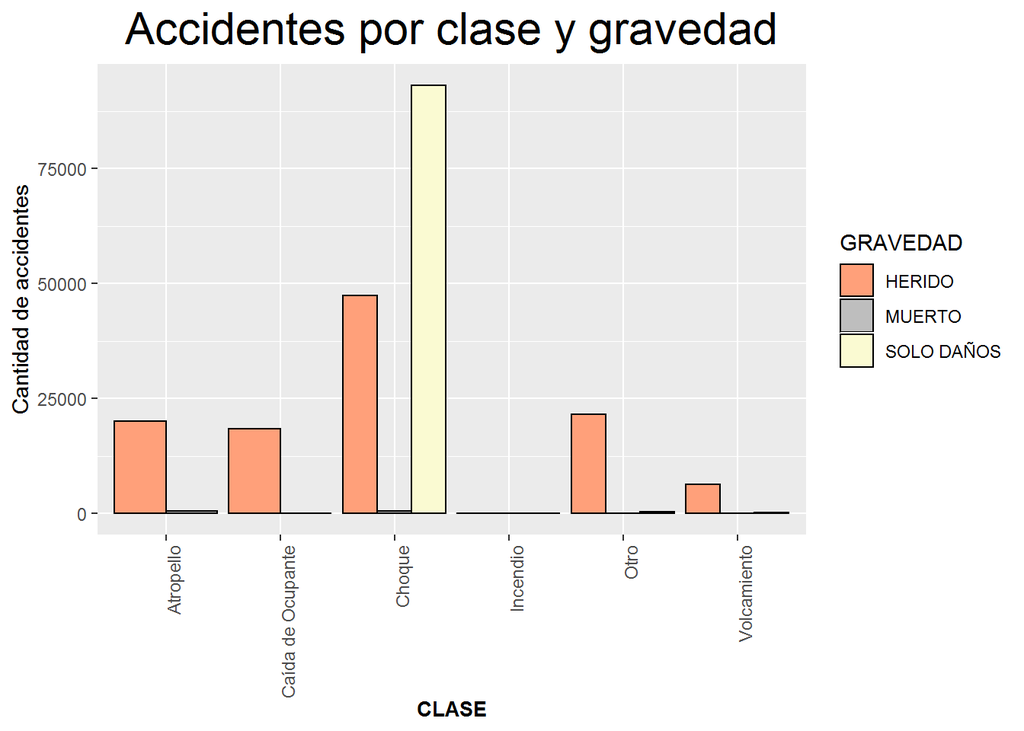

Cuando analizamos los accidentes por comuna, podemos evidenciar que La Candelaria es la comuna de Medellín, con más accidentalidad, seguida de Laureles-Estadio y Castilla, también podemos evidenciar que donde menos se produce accidentalidad es en los corregimientos de y la zona nororiental de la ciudad.

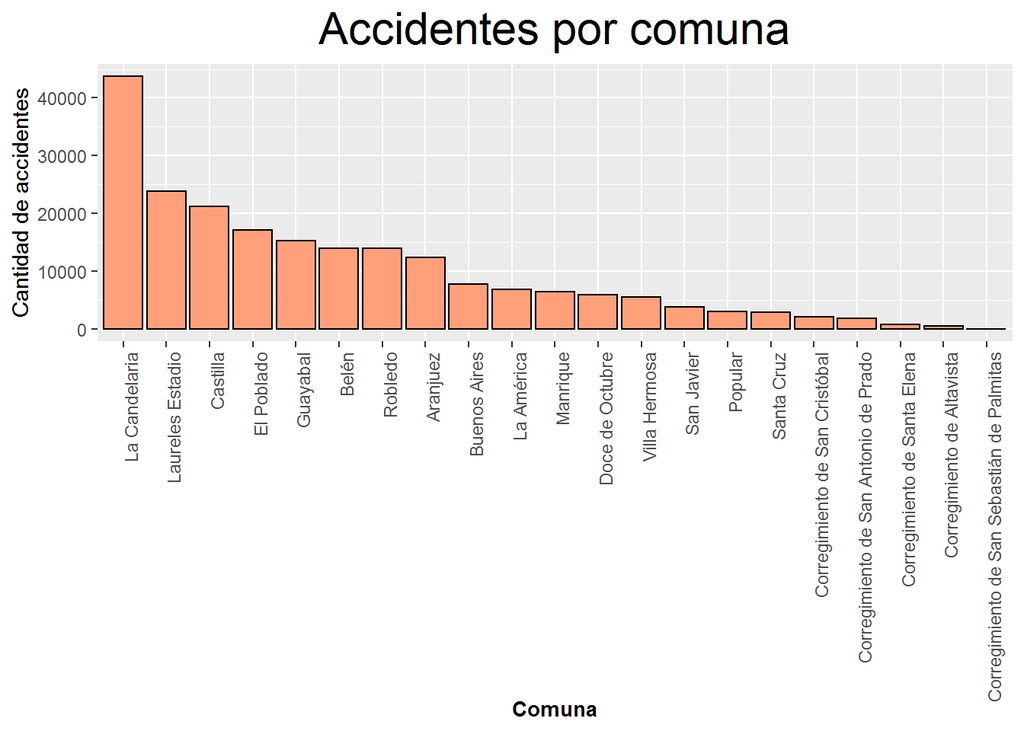

Al analizar la accidentalidad por barrio, podemos evidenciar que es en la zona céntrica y sur de la ciudad donde se concentran la mayor parte de accidentes en las vías, estos datos no pueden dar indicios de cómo podremos agrupar categóricamente, mas adelante.

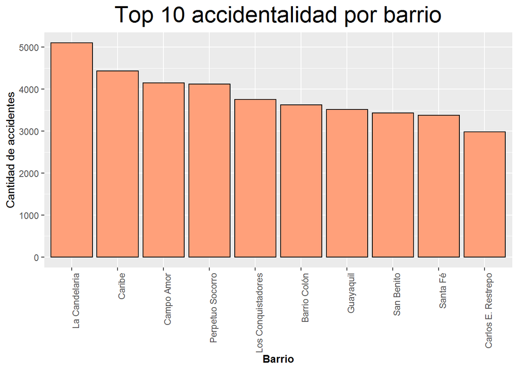

### VISUALIZACIÓN

Para la visualización de los datos, se tuvo en cuenta la clase de accidente, la fecha de ocurrencia del accidente y la comuna. El usuario puede seleccionar la clase de accidente que esté interesado en consultar (choque, incendio, volcamiento, caída de ocupante, atropello y otro), además de una ventana de tiempo y la comuna, como se muestra en la figura:

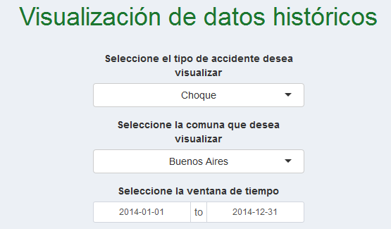

Una vez seleccionadas las variables de consulta, se podrán visualizar en el mapa, donde están agrupadas por gravedad (herido, muerto o solo daños), ademas de la cantidad de cada suceso. Utilizando la función leaflet de R:

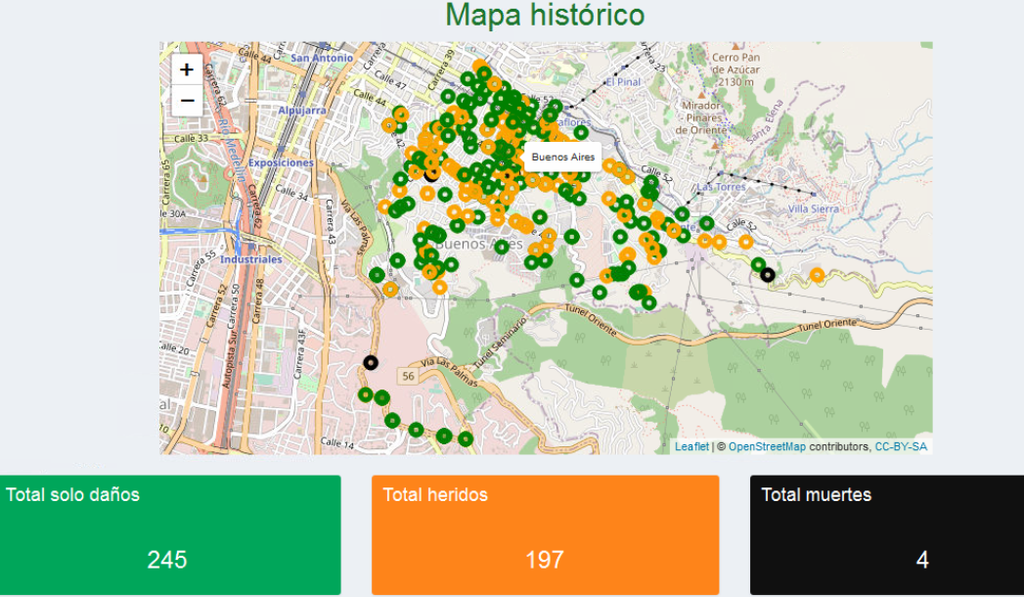

Si se desea ver en detalle por cada barrio el número de accidentes y la gravedad del accidente ocurrido por la clase de accidente seleccionada, se incorporó una opción para ver el detalle de los barrios, con el botón VISUALIZAR DETALLE BARRIOS, que lo que hace es retornar una tabla con el detalle de los barrios de la consulta previamente establecida.

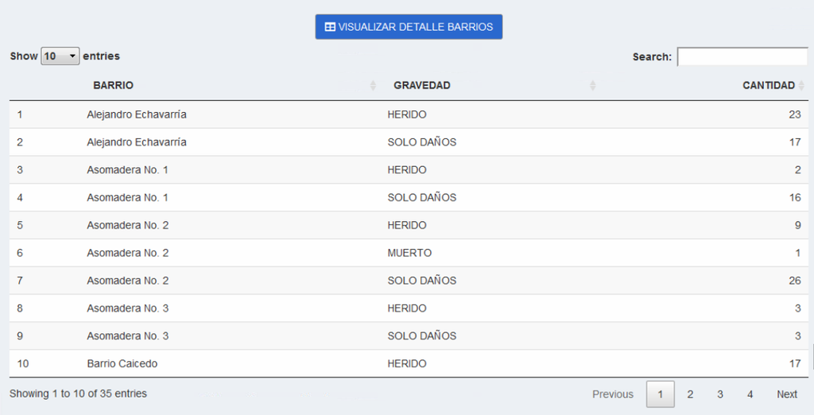

### AGRUPAMIENTO

Con la base de datos depurada se subdivide en tres grupos de datos:

- La primera base de datos resume los datos agrupados por barrios y comunas, cuando la gravedad del accidente es HERIDO y se crea la variable PROMEDIO_HERIDOS_x_MES.

```
## # A tibble: 5 x 4
## # Groups:   COMUNA, BARRIO [5]
##   COMUNA   BARRIO              CANTIDAD_HERIDOS PROMEDIO_HERIDOS_X_MES
##   <fct>    <fct>                          <int>                  <dbl>
## 1 Aranjuez Aranjuez                         263                   4.38
## 2 Aranjuez Berlin                           543                   9.05
## 3 Aranjuez Bermejal-Los Alamos              161                   2.68
## 4 Aranjuez Brasilia                         359                   5.98
## 5 Aranjuez Campo Valdés No. 1               901                  15.0
```

- La segunda base de datos resume los datos agrupados por barrios y comunas, cuando la gravedad del accidente es MUERTO y se crea la variable PROMEDIO_MUERTES_X_MES.

```
## # A tibble: 5 x 4
## # Groups:   COMUNA, BARRIO [5]
##   COMUNA   BARRIO              CANTIDAD_MUERTES PROMEDIO_MUERTES_X_MES
##   <fct>    <fct>                          <int>                  <dbl>
## 1 Aranjuez Aranjuez                          10                 0.167
## 2 Aranjuez Berlin                             5                 0.0833
## 3 Aranjuez Bermejal-Los Alamos                2                 0.0333
## 4 Aranjuez Brasilia                           5                 0.0833
## 5 Aranjuez Campo Valdés No. 1                 6                 0.1
```

La tercera base de datos resume los datos agrupados por barrios y comunas, cuando la gravedad del accidente es SOLO DAÑOS y se crea la variable PROMEDIO_DAÑOS_X_MES.

```
## # A tibble: 5 x 4
## # Groups:   COMUNA, BARRIO [5]
##   COMUNA   BARRIO              CANTIDAD_SOLO_DAÑOS PROMEDIO_DAÑOS_X_MES
##   <fct>    <fct>                             <int>                <dbl>
## 1 Aranjuez Aranjuez                            108                 1.8
## 2 Aranjuez Berlin                              262                 4.37
## 3 Aranjuez Bermejal-Los Alamos                  69                 1.15
## 4 Aranjuez Brasilia                            136                 2.27
## 5 Aranjuez Campo Valdés No. 1                  303                 5.05
```

Luego se unifican las bases de datos en una sola base de datos, además lo valores nulos o NA para las variables calculadas anteriormente se reemplazan por 0. Se crean dos nuevas variables, que son TOTAL_ACCIDENTES1 y TOTAL_ACCIDENTES, donde:

- TOTAL_ACCIDENTES1: es la suma total de los accidentes en el barrio.
- TOTAL_ACCIDENTES: es la suma total de los accidentes en el barrio, cuya gravedad es herido o muerto.
- POR_HERIDOS: indica que porcentaje sobre los accidentes totales, derivaron en hechosdonde se produjeron heridos o muertos.

```
##                 BARRIO                     COMUNA CANTIDAD_HERIDOS
## 1          Aguas Frias Corregimiento de Altavista               63
## 2       Aldea Pablo VI                    Popular               64
## 3           Alejandría                 El Poblado              132
## 4 Alejandro Echavarría               Buenos Aires              595
## 5        Alfonso López                   Castilla              772
##   PROMEDIO_HERIDOS_X_MES CANTIDAD_MUERTES PROMEDIO_MUERTES_X_MES
## 1               1.050000                0             0.00000000
## 2               1.066667                2             0.03333333
## 3               2.200000                1             0.01666667
## 4               9.916667                2             0.03333333
## 5              12.866667                6             0.10000000
##   CANTIDAD_SOLO_DAÑOS PROMEDIO_DAÑOS_X_MES TOTAL_ACCIDENTES1 TOTAL_ACCIDENTES
## 1                  22            0.3666667                85               63
## 2                  17            0.2833333                83               66
## 3                 366            6.1000000               499              133
## 4                 243            4.0500000               840              597
## 5                 369            6.1500000              1147              778
##   POR_HERIDOS
## 1    74.11765
## 2    79.51807
## 3    26.65331
## 4    71.07143
## 5    67.82912
```

A continuación, se crea un data frame con las variables que van a ser utilizadas para clusterizacion de los barrios, que seran TOTAL_ACCIDETNES1 y POR_HERIDOS.

```
##                 BARRIO TOTAL_ACCIDENTES1 POR_HERIDOS
## 1          Aguas Frias                85    74.11765
## 2       Aldea Pablo VI                83    79.51807
## 3           Alejandría               499    26.65331
## 4 Alejandro Echavarría               840    71.07143
## 5        Alfonso López              1147    67.82912
```

Finalmente se escalan los datos con la funcion scale de R, para evitar problemas de dimensionamiento.

```
##      TOTAL_ACCIDENTES1 POR_HERIDOS
## [1,]        0.08045251   1.1417585
## [2,]        0.07855951   1.2249503
## [3,]        0.47230356   0.4105856
## [4,]        0.79506011   1.0948325
## [5,]        1.08563564   1.0448857
```

Para encontrar el k optimo de clusters, aplicaremos el método del codo ó Elbow Method, apartir de la optimización del WCSS, el cual se basa fundamentalmente en agrupar los datos de entrada en un total de k conjuntos definidos por el centroide, cuya distancia con los puntos que pertenecen a cada uno de los datos es la menor posible. Evaluando posibles valores de k entre 1 y 10.

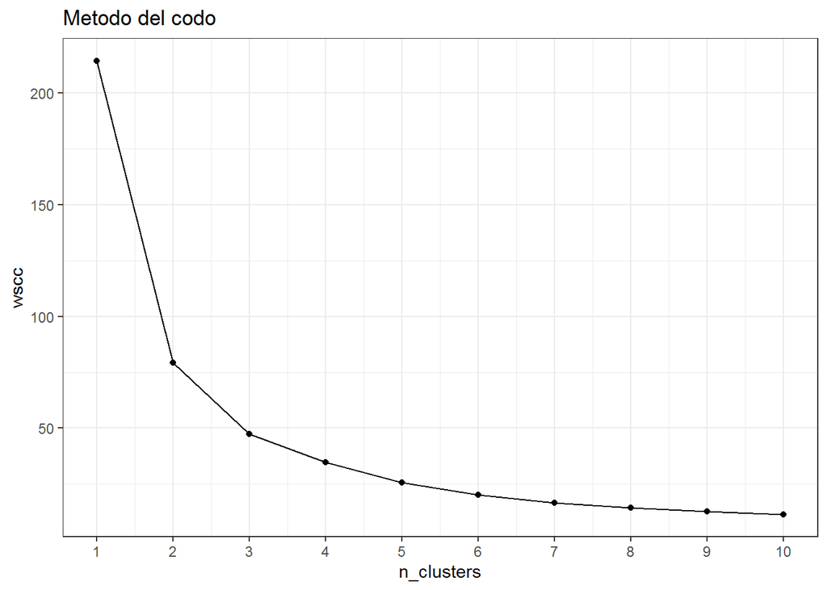

Al evaluar el resultado, se evidencia que la grafica tiene a ser mas estable en k=4, es por esto que se decide trabajar con un k=4.

Se deciden tener en cuenta para la separacion de grupos, dos parámetros de seleccion:

- Accidentalidad: se considerará un barrio con accidentalidad alta aquellos donde se superen los 15 accidentes por mes. Si la cantidad es menor a 15 accidentes por mes se considerará accidentalidad baja.
- Probabilidad de lesiones: se considerará un barrio con un alta probabilidad de lesiones aquellos que superen un 60% de accidentes que resultaron en heridos o muertos, sobre el total de accidentes. Si es menor a 60% se considerará baja probalilidad de lesiones.

Los grupos serán definidos de acuerdo a los paramétros anteriores de la siguiente manera:

- Grupo 1: Barrios de alta accidentalidad con una alta probabilidad de lesiones.
- Grupo 2: Barrios de alta accidentalidad con una baja probabilidad de lesiones.
- Grupo 3 : Barrios de baja accidentalidad con una alta probabilidad de lesiones.
- Grupo 4 : Barrios de baja accidentalidad con una baja probabilidad de lesiones.

Al aplicar el agrupamiento de los datos, el data frame queda definido con su número de grupo.

```
##                 BARRIO                     COMUNA CANTIDAD_HERIDOS
## 1          Aguas Frias Corregimiento de Altavista               63
## 2       Aldea Pablo VI                    Popular               64
## 3           Alejandría                 El Poblado              132
## 4 Alejandro Echavarría               Buenos Aires              595
## 5        Alfonso López                   Castilla              772
##   PROMEDIO_HERIDOS_X_MES CANTIDAD_MUERTES PROMEDIO_MUERTES_X_MES
## 1               1.050000                0             0.00000000
## 2               1.066667                2             0.03333333
## 3               2.200000                1             0.01666667
## 4               9.916667                2             0.03333333
## 5              12.866667                6             0.10000000
##   CANTIDAD_SOLO_DAÑOS PROMEDIO_DAÑOS_X_MES TOTAL_ACCIDENTES1 TOTAL_ACCIDENTES
## 1                  22            0.3666667                85               63
## 2                  17            0.2833333                83               66
## 3                 366            6.1000000               499              133
## 4                 243            4.0500000               840              597
## 5                 369            6.1500000              1147              778
##   POR_HERIDOS GRUPO         X        Y
## 1    74.11765     3 -75.62536 6.234341
## 2    79.51807     3 -75.54205 6.288312
## 3    26.65331     4 -75.57098 6.201526
## 4    71.07143     3 -75.54626 6.237197
## 5    67.82912     1 -75.57441 6.283489
```

Los barrios quedaron distribuidos en los grupos de la siguiente forma:

```
## # A tibble: 4 x 2
##   GRUPO CANTIDAD_BARRIOS
##   <dbl>            <int>
## 1     1               21
## 2     2               56
## 3     3              162
## 4     4               78
```

A continuación con la libreria leaflet de R, se grafican estos grupos en el mapa de acuerdo con su ubicación segun el promedio de su longitud, y latitud por barrio, asignandole un color a cada grupo.

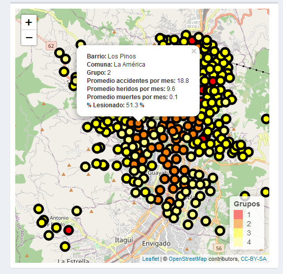